# Ecommerce Online Platform and Website Analysis

Subin Kim

2021/6/2

## **I. Introduction**

### 1. Background

##### “Ecommerce, also known as electronic commerce or internet commerce, refers to the buying and selling of goods or services using the internet, and the transfer of money and data to execute these transactions. Ecommerce is often used to refer to the sale of physical products online, but it can also describe any kind of commercial transaction that is facilitated through the internet. Whereas e-business refers to all aspects of operating an online business, ecommerce refers specifically to the transaction of goods and services (Shopify Business Encyclopedia, 2021).”

##### The pandemic COVID-19 has been an opportunity for ecommerce companies to be a great part of people’s lives as the world dived into a more digital and online-based lifestyle. Many aspects of people’s lives changed in terms of communication and everyday life wherein everthing switched to non-face-to-face. But as this happens, more and more companies are joining in the ecommerce market. Consequently, competition is becoming fierce and it has become more important for companies to be able to reach more customers online and be able to catch their attention for them to be actual buyers or customers. Based on a report from Shopify, at the height of the COVID-19 pandemic, 10 years of ecommerce growth happened in just 90 days. The global survey across 11 markets conducted by Shopify showed that 84% of consumers shopped online during the pandemic. As countries locked down and retailers and stores were forced to close, ecommerce market reached 16.4% of total global retail sales which is the highest point in the time series (ShopifyPlus, 2021). Due to the fiercely rising competition, it is important for companies to meet the needs of customers in a fast, specific, and effecient manner.

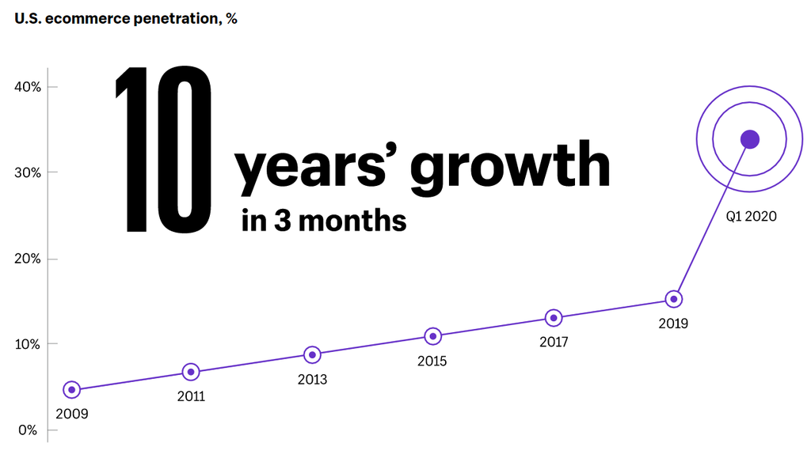

### 4. Beneficiaries and Limitations

##### The beneficiaries are the companies particpating in the ecommerce market.

##### The limitations of the study is the insufficient data used in the study. For this study to be more evident, it requires the actual database of many companies that are actually participating in the ecommerce market. However, due to confidentiality, it is difficult to get those data sets. Instead, the data sets are gathered by survey results of studies and university research institutions. This will serve as a guide date that can be appropriately applied to general situations. Lastly, there is limited time.

## **II. Data**

```r
# Import data
platform <- read_csv("Dummy_Data.csv")
sns <- read_csv("Most_Used_Social_Media_Platforms.csv")
website <- read_csv("online_shoppers_intention.csv")
keyword <- read_csv("ecommerce_search_relevance.csv")
```

### 1. Datasets

#### Data 1:

```r
platform
```

| TV | Radio | Social Media | Influencer | Sales |
| --- | --- | --- | --- | --- |
| 16 | 6.56623079 | 2.907982773 | Mega | 54.73276 |
| 13 | 9.23776457 | 2.409567204 | Mega | 46.67790 |
| 41 | 15.88644602 | 2.913410175 | Mega | 150.17783 |
| 83 | 30.02002826 | 6.922303959 | Mega | 298.24634 |
| 15 | 8.43740768 | 1.405998150 | Micro | 56.59418 |
| 29 | 9.61438204 | 1.027163490 | Mega | 105.88915 |
| 55 | 24.89381148 | 4.273602146 | Micro | 198.67982 |
| 31 | 17.35504181 | 2.289854925 | Nano | 108.73393 |
| 76 | 24.64889821 | 7.130115956 | Macro | 270.18940 |
| 13 | 0.43112782 | 2.229423022 | Mega | 48.28058 |

[output cut: 990 more lines]

##### This data was retrieved from a data science website, “kaggle.com”. It was shared on March of 2021 by Harriman Samuel Saragih who is a professor of ‘Data-Driven Marketing’ and ‘Data Science for Business.’ There are five columns consisting of TV promotion budget (in millions), radio promotion budget (in millions), Social Media promotion budget (in millions), type of influencers, and sales (in million). The independent variables are TV promotion budget, Radio promotion budget, Social Media promotion budget and type of influencers. The ‘type of influencers’ variable is a cateogorical variable consisting of 4 levels: Mega, Macro, Nano, and Micro. The dependent or output variable is the sales.

#### Data 2:

```r
sns
```

| Platform(in millions) | Platform Type | Image URL | Quarter 1 2009 | Quarter 2 2009 | Quarter 3 2009 | Quarter 4 2009 | Quarter 1 2010 | Quarter 2 2010 | Quarter 3 2010 | Quarter 4 2010 | Quarter 1 2011 | Quarter 2 2011 | Quarter 3 2011 | Quarter 4 2011 | Quarter 1 2012 | Quarter 2 2012 | Quarter 3 2012 | Quarter 4 2012 | Quarter 1 2013 | Quarter 2 2013 | Quarter 3 2013 | Quarter 4 2013 | Quarter 1 2014 | Quarter 2 2014 | Quarter 3 2014 | Quarter 4 2014 | Quarter 1 2015 | Quarter 2 2015 | Quarter 3 2015 | … |
| --- | --- | --- | --- | --- | --- | --- | --- | --- | --- | --- | --- | --- | --- | --- | --- | --- | --- | --- | --- | --- | --- | --- | --- | --- | --- | --- | --- | --- | --- | --- |
| Facebook | Network | https://logodix.com/logo/28357.png | 197 | 242 | 305 | 360 | 431.00 | 482.00 | 550.0 | 608.00 | 680.00 | 739.00 | 800.0 | 845.0 | 901.0 | 955.0 | 1007.0 | 1056.0 | 1110.0 | 1155.00 | 1189.00 | 1228.00 | 1276.00 | 1317.00 | 1350.00 | 1393.00 | 1441.00 | 1490.00 | 1545.00 | … |
| Snapchat | Media sharing | https://logodix.com/logo/1218639.jpg | NA | NA | NA | NA | NA | NA | NA | NA | NA | NA | NA | NA | NA | NA | NA | NA | NA | NA | NA | NA | 46.00 | 57.00 | 62.00 | 71.00 | 80.00 | 86.00 | 94.00 | … |
| Instagram | Media sharing | https://logodix.com/logo/4269.png | NA | NA | NA | NA | NA | NA | NA | NA | NA | NA | NA | NA | NA | NA | NA | NA | 95.0 | 130.00 | 140.00 | 150.00 | 200.00 | 233.30 | 266.60 | 300.00 | 325.00 | 350.00 | 375.00 | … |
| Messenger | Messaging | https://logodix.com/logo/452349.png | NA | NA | NA | NA | NA | NA | NA | NA | NA | NA | NA | NA | NA | NA | NA | NA | NA | NA | NA | NA | NA | 200.00 | 350.00 | 500.00 | 600.00 | 700.00 | 750.00 | … |
| Tumblr | Blogging | https://logodix.com/logo/486597.jpg | NA | NA | NA | NA | NA | NA | NA | NA | NA | NA | 17.5 | 28.0 | 50.0 | 62.6 | 69.5 | 76.4 | 88.6 | 101.80 | 122.40 | 141.40 | 166.30 | 181.10 | 195.10 | 207.30 | 220.80 | 227.10 | 246.60 | … |
| LinkedIn | Network | https://logodix.com/logo/91001.png | 37 | 42 | 48 | 55 | 64.00 | 78.00 | 81.0 | 90.00 | 102.00 | 116.00 | 131.0 | 145.0 | 161.0 | 174.0 | 187.0 | 202.0 | 218.0 | 238.00 | 259.00 | 277.00 | 296.00 | 313.00 | 332.00 | 347.00 | 364.00 | 380.00 | 396.00 | … |
| TikTok | Media sharing | https://logodix.com/logo/51106.png | NA | NA | NA | NA | NA | NA | NA | NA | NA | NA | NA | NA | NA | NA | NA | NA | NA | NA | NA | NA | NA | NA | NA | NA | NA | NA | NA | … |
| Pinterest | Media sharing | https://logodix.com/logo/4235.png | NA | NA | NA | NA | NA | NA | NA | NA | NA | NA | NA | NA | NA | NA | NA | NA | NA | NA | NA | NA | NA | NA | NA | NA | NA | NA | NA | … |
| Twitter | Blogging | https://logodix.com/logo/14524.png | NA | NA | NA | NA | 30.00 | 40.00 | 49.0 | 54.00 | 68.00 | 85.00 | 101.0 | 117.0 | 138.0 | 151.0 | 167.0 | 185.0 | 204.0 | 218.00 | 231.70 | 241.00 | 255.00 | 271.00 | 284.00 | 288.00 | 302.00 | 304.00 | 307.00 | … |
| Youtube | Media sharing | https://logodix.com/logo/2735.png | NA | NA | NA | NA | NA | NA | NA | NA | NA | NA | NA | NA | NA | NA | NA | NA | NA | NA | NA | NA | NA | NA | NA | NA | NA | NA | NA | … |

[output cut: 14 more lines]

##### This data was also retrieved from the kaggle website. It was shared from another data science website called Flourish at October of 2020. This shows the most used social media platforms from year 2009 to 2019. There are 45 columns in the data which are the platform name, platform type, and the utility rate of the time series from 2009 to 2019.

#### Data 3:

```r
website
```

| Administrative | Administrative_Duration | Informational | Informational_Duration | ProductRelated | ProductRelated_Duration | BounceRates | ExitRates | PageValues | SpecialDay | Month | OperatingSystems | Browser | Region | TrafficType | VisitorType | Weekend | Revenue |
| --- | --- | --- | --- | --- | --- | --- | --- | --- | --- | --- | --- | --- | --- | --- | --- | --- | --- |
| 0 | 0.00000 | 0 | 0.00000 | 1 | 0.000000 | 0.200000000 | 0.200000000 | 0.000000 | 0.0 | Feb | 1 | 1 | 1 | 1 | Returning_Visitor | FALSE | FALSE |
| 0 | 0.00000 | 0 | 0.00000 | 2 | 64.000000 | 0.000000000 | 0.100000000 | 0.000000 | 0.0 | Feb | 2 | 2 | 1 | 2 | Returning_Visitor | FALSE | FALSE |
| 0 | 0.00000 | 0 | 0.00000 | 1 | 0.000000 | 0.200000000 | 0.200000000 | 0.000000 | 0.0 | Feb | 4 | 1 | 9 | 3 | Returning_Visitor | FALSE | FALSE |
| 0 | 0.00000 | 0 | 0.00000 | 2 | 2.666667 | 0.050000000 | 0.140000000 | 0.000000 | 0.0 | Feb | 3 | 2 | 2 | 4 | Returning_Visitor | FALSE | FALSE |
| 0 | 0.00000 | 0 | 0.00000 | 10 | 627.500000 | 0.020000000 | 0.050000000 | 0.000000 | 0.0 | Feb | 3 | 3 | 1 | 4 | Returning_Visitor | TRUE | FALSE |
| 0 | 0.00000 | 0 | 0.00000 | 19 | 154.216667 | 0.015789474 | 0.024561404 | 0.000000 | 0.0 | Feb | 2 | 2 | 1 | 3 | Returning_Visitor | FALSE | FALSE |
| 0 | 0.00000 | 0 | 0.00000 | 1 | 0.000000 | 0.200000000 | 0.200000000 | 0.000000 | 0.4 | Feb | 2 | 4 | 3 | 3 | Returning_Visitor | FALSE | FALSE |
| 1 | 0.00000 | 0 | 0.00000 | 0 | 0.000000 | 0.200000000 | 0.200000000 | 0.000000 | 0.0 | Feb | 1 | 2 | 1 | 5 | Returning_Visitor | TRUE | FALSE |
| 0 | 0.00000 | 0 | 0.00000 | 2 | 37.000000 | 0.000000000 | 0.100000000 | 0.000000 | 0.8 | Feb | 2 | 2 | 2 | 3 | Returning_Visitor | FALSE | FALSE |
| 0 | 0.00000 | 0 | 0.00000 | 3 | 738.000000 | 0.000000000 | 0.022222222 | 0.000000 | 0.4 | Feb | 2 | 4 | 1 | 2 | Returning_Visitor | FALSE | FALSE |

[output cut: 990 more lines]

##### The data was retrieved from University of California Irvine Machine Learning Respiratory collected by Okan C. Sakar and Kastro Yomi at May 2018. The data consists of 18 columns. There are 10 numerical variables and 8 categorical variables. “Administrative”, “Administrative Duration”, “Informational”, “Informational Duration”, “Product Related” and “Product Related Duration” represent the number of different types of pages visited by the visitor in that session and total time spent in each of these page categories. The values of these features are derived from the URL information of the pages visited by the user and updated in real time when a user takes an action such as moving from one page to another. The “Bounce Rate”, “Exit Rate” and “Page Value” features represent the metrics measured by “Google Analytics” for each page in the e-commerce site. The value of “Bounce Rate” feature for a web page refers to the percentage of visitors who enter the site from that page and then leave (“bounce”) without triggering any other requests to the analytics server during that session. The value of “Exit Rate” feature for a specific web page is calculated as for all pageviews to the page, the percentage that were the last in the session. The “Page Value” feature represents the average value for a web page that a user visited before completing an e-commerce transaction. The “Special Day” feature indicates the closeness of the site visiting time to a specific special day (e.g. Mother’s Day, Valentine’s Day) in which the sessions are more likely to be finalized with transaction. The dataset also includes operating system, browser, region, traffic type, visitor type as returning or new visitor, a Boolean value indicating whether the date of the visit is weekend, and month of the year.

#### Data 4:

```r
keyword
```

| _unit_id | relevance | relevance:variance | product_image | product_link | product_price | product_title | query | rank | source | url | product_description |
| --- | --- | --- | --- | --- | --- | --- | --- | --- | --- | --- | --- |
| 711158459 | 3.67 | 0.471 | http://thumbs2.ebaystatic.com/d/l225/m/mzvzEUIknaQclZ801YCY1ew.jpg | http://www.ebay.com/itm/Sony-PlayStation-4-PS4-Latest-Model-500-GB-Jet-Black-Console-/321459436277?pt=LH_DefaultDomain_0&hash=item4ad879baf5 | $329.98 | Sony PlayStation 4 (PS4) (Latest Model)- 500 GB Jet Black Console | playstation 4 | 1 | eBay | http://www.ebay.com/sch/i.html?_from=R40&_trksid=p2050601.m570.l1313.TR11.TRC1.A0.H0.Xplant.TRS0&_nkw=playstation%204 | The PlayStation 4 system opens the door to an incredible journey through immersive new gaming worlds and a deeply connected gaming community. Step into living, breathing worlds where you are hero of y… |
| 711158460 | 4.00 | 0.000 | http://thumbs3.ebaystatic.com/d/l225/m/mJNDmSyIS3vUasKIJEBy4Cw.jpg | http://www.ebay.com/itm/Sony-PlayStation-4-Latest-Model-500-GB-Jet-Black-Console-/131467224962?pt=LH_DefaultDomain_0&hash=item1e9c0ea782 | $324.84 | Sony PlayStation 4 (Latest Model)- 500 GB Jet Black Console | playstation 4 | 2 | eBay | http://www.ebay.com/sch/i.html?_from=R40&_trksid=p2050601.m570.l1313.TR11.TRC1.A0.H0.Xplant.TRS0&_nkw=playstation%204 | The PlayStation 4 system opens the door to an incredible journey through immersive new gaming worlds and a deeply connected gaming community. Step into living, breathing worlds where you are hero of y… |
| 711158461 | 4.00 | 0.000 | http://thumbs4.ebaystatic.com/d/l225/m/m10NZXArmiIkpkTDDkAUVvA.jpg | http://www.ebay.com/itm/Sony-PlayStation-4-PS4-500-GB-Jet-Black-Console-/171564913575?pt=LH_DefaultDomain_0&hash=item27f210d3a7 | $324.83 | Sony PlayStation 4 PS4 500 GB Jet Black Console | playstation 4 | 3 | eBay | http://www.ebay.com/sch/i.html?_from=R40&_trksid=p2050601.m570.l1313.TR11.TRC1.A0.H0.Xplant.TRS0&_nkw=playstation%204 | The PlayStation 4 system opens the door to an incredible journey through immersive new gaming worlds and a deeply connected gaming community. Step into living, breathing worlds where you are hero of y… |
| 711158462 | 3.67 | 0.471 | http://thumbs2.ebaystatic.com/d/l225/m/mZZXTmAE8WZDH1l_E_PPAkg.jpg | http://www.ebay.com/itm/Sony-PlayStation-4-500GB-The-Last-of-Us-Remastered-Bundle-Black-/261867581805?pt=LH_DefaultDomain_0&hash=item3cf886316d | $350.00 | Sony - PlayStation 4 500GB The Last of Us Remastered Bundle - Black | playstation 4 | 4 | eBay | http://www.ebay.com/sch/i.html?_from=R40&_trksid=p2050601.m570.l1313.TR11.TRC1.A0.H0.Xplant.TRS0&_nkw=playstation%204 | NA |
| 711158463 | 3.33 | 0.471 | http://thumbs3.ebaystatic.com/d/l225/m/mzvzEUIknaQclZ801YCY1ew.jpg | http://www.ebay.com/itm/Sony-PlayStation-4-PS4-Latest-Model-500-GB-Jet-Black-Console-/121512215166?pt=LH_DefaultDomain_0&hash=item1c4ab1427e | $308.00\nTrending at\n$319.99 | Sony PlayStation 4 (PS4) (Latest Model)- 500 GB Jet Black Console | playstation 4 | 5 | eBay | http://www.ebay.com/sch/i.html?_from=R40&_trksid=p2050601.m570.l1313.TR11.TRC1.A0.H0.Xplant.TRS0&_nkw=playstation%204 | The PlayStation 4 system opens the door to an incredible journey through immersive new gaming worlds and a deeply connected gaming community. Step into living, breathing worlds where you are hero of y… |
| 711158464 | 3.20 | 0.748 | http://thumbs4.ebaystatic.com/d/l225/m/mzvzEUIknaQclZ801YCY1ew.jpg | http://www.ebay.com/itm/Sony-PlayStation-4-PS4-Latest-Model-500-GB-Jet-Black-Console-/321739452651?pt=LH_DefaultDomain_0&hash=item4ae92a70eb | $310.00 | Sony PlayStation 4 (PS4) (Latest Model)- 500 GB Jet Black Console | playstation 4 | 6 | eBay | http://www.ebay.com/sch/i.html?_from=R40&_trksid=p2050601.m570.l1313.TR11.TRC1.A0.H0.Xplant.TRS0&_nkw=playstation%204 | The PlayStation 4 system opens the door to an incredible journey through immersive new gaming worlds and a deeply connected gaming community. Step into living, breathing worlds where you are hero of y… |
| 711158465 | 4.00 | 0.000 | http://thumbs4.ebaystatic.com/d/l225/m/m9TQTiWcWig7SeQh9algLZg.jpg | http://www.ebay.com/itm/BRAND-NEW-Sony-PlayStation-4-BUNDLE-500gb-/281672602591?pt=LH_DefaultDomain_0&hash=item4194fed3df | $910.00 | BRAND NEW Sony PlayStation 4 BUNDLE 500gb | playstation 4 | 7 | eBay | http://www.ebay.com/sch/i.html?_from=R40&_trksid=p2050601.m570.l1313.TR11.TRC1.A0.H0.Xplant.TRS0&_nkw=playstation%204 | NA |
| 711158466 | 4.00 | 0.000 | http://thumbs4.ebaystatic.com/d/l225/m/mTZYG5N6xWfBi4Ok03HmpMw.jpg | http://www.ebay.com/itm/Sony-PlayStation-4-500GB-Dualshock-Wireless-Control-HDMI-Gaming-Console-Refurb-/291398220855?pt=LH_DefaultDomain_0&hash=item43d8affc37 | $299.99 | Sony PlayStation 4 500GB, Dualshock Wireless Control, HDMI Gaming Console Refurb | playstation 4 | 8 | eBay | http://www.ebay.com/sch/i.html?_from=R40&_trksid=p2050601.m570.l1313.TR11.TRC1.A0.H0.Xplant.TRS0&_nkw=playstation%204 | The PlayStation 4 system opens the door to an incredible journey through immersive new gaming worlds and a deeply connected gaming community. Step into living, breathing worlds where you are hero of y… |
| 711158467 | 3.75 | 0.433 | http://thumbs2.ebaystatic.com/d/l225/m/mX5Qphrygqeoi7tAH5eku2A.jpg | http://www.ebay.com/itm/Sony-PlayStation-4-Latest-Model-500-GB-Jet-Black-Console-w-2-Controllers-/191563117865?pt=LH_DefaultDomain_0&hash=item2c9a0d3529 | $350.00 | Sony PlayStation 4 (Latest Model)- 500 GB Jet Black Console w/ 2 Controllers | playstation 4 | 9 | eBay | http://www.ebay.com/sch/i.html?_from=R40&_trksid=p2050601.m570.l1313.TR11.TRC1.A0.H0.Xplant.TRS0&_nkw=playstation%204 | NA |
| 711158468 | 2.33 | 0.471 | http://thumbs2.ebaystatic.com/d/l225/m/mGjN4IrJ0O8kKD_TYMWgGgQ.jpg | http://www.ebay.com/itm/Sony-PlayStation-4-Latest-Model-500-GB-Jet-Black-Console-NEW-/191323651417?pt=LH_DefaultDomain_0&hash=item2c8bc73d59 | $469.97 | Sony PlayStation 4 (Latest Model)- 500 GB Jet Black Console *NEW* | playstation 4 | 10 | eBay | http://www.ebay.com/sch/i.html?_from=R40&_trksid=p2050601.m570.l1313.TR11.TRC1.A0.H0.Xplant.TRS0&_nkw=playstation%204 | The PlayStation 4 system opens the door to an incredible journey through immersive new gaming worlds and a deeply connected gaming community. Step into living, breathing worlds where you are hero of y… |

[output cut: 990 more lines]

##### This data was retrieved from the kaggle website and was shared by CrowdFlower (Datasets Resource Center) on July 28 2015. The dataset focuses on ecommerce keyword search relevance and consists of 12 columns. The variables are the following: unit id, relevance, relevance rate, product image, product link, product price, product title, query/category, rank, source, url, and product description.

### 2. Data Manipulation

#### 1) Platform Advertisement Budget and Sales

```r
platform_new <- platform %>%
  # rename variable for easy finding
  rename(Social_Media = "Social Media") %>%
  # round to two decimal places
  mutate(
    Radio = round(Radio, 2),
    Social_Media = round(Social_Media, 2),
    Sales = round(Sales, 2)
  ) %>%
  # variable selection
  select(-Influencer) %>%
  # arrange from highest to lowest sales
  arrange(desc(Sales))

platform_new
```

| TV | Radio | Social_Media | Sales |
| --- | --- | --- | --- |
| 100 | 42.23 | 8.98 | 364.08 |
| 100 | 32.15 | 7.57 | 362.04 |
| 100 | 34.49 | 9.19 | 360.40 |
| 100 | 32.74 | 5.36 | 360.11 |
| 100 | 27.78 | 5.28 | 359.04 |
| 100 | 34.37 | 5.77 | 358.90 |
| 100 | 28.66 | 3.52 | 358.42 |
| 100 | 38.47 | 5.79 | 358.35 |
| 100 | 30.11 | 8.05 | 357.79 |
| 100 | 31.42 | 2.92 | 357.59 |

[output cut: 990 more lines]

#### 2) Social Media Platform Usage Per Year

```r
sns_new <- sns %>%
  # variable selection and formatting
  select(-c("Image URL", "Unnamed: 44")) %>%
  rename(platform = "Platform(in millions)", type = "Platform Type") %>%
  # year variable
  gather(year, usage, -c(platform, type)) %>%
  drop_na() %>%
  mutate(
    year = as.numeric(str_extract(year, "(2)(0)([01])([0-9])"))
  ) %>%
  # summarize by year and platform
  arrange(year, platform) %>%
  group_by(year, platform) %>%
  summarise(usage = sum(usage))

sns_new
```

| year | platform | usage |
| --- | --- | --- |
| 2009 | Facebook | 1104.00 |
| 2009 | LinkedIn | 182.00 |
| 2010 | Facebook | 2071.00 |
| 2010 | LinkedIn | 313.00 |
| 2010 | QQ | 647.60 |
| 2010 | Twitter | 173.00 |
| 2010 | Yelp | 139.22 |
| 2011 | Facebook | 3064.00 |
| 2011 | LinkedIn | 494.00 |
| 2011 | QQ | 2761.00 |

[output cut: 145 more lines]

#### 3) Website Page Type Frequency, Duration, and Others

```r
website_new <- website %>%
  # variable selection
  select(-(Month:TrafficType))%>%
  # visitor variable
  mutate(
    VisitorType = str_extract(VisitorType, "([^_]+)")
  ) %>%
  # rename variable names for easy find
  rename(administrative = Administrative,
         administrative_duration = Administrative_Duration,
         informational = Informational,
         informational_duration = Informational_Duration,
         product_related = ProductRelated,
         product_related_duration = ProductRelated_Duration,
         visitor_type = VisitorType,
         exit_rates = ExitRates,
         bounce_rates = BounceRates,
         page_values = PageValues,
         holiday = SpecialDay,
         weekend = Weekend,
         revenue = Revenue
  ) %>%
  # reorder variables
  select(visitor_type, administrative:holiday, weekend, revenue)

website_new
```

| visitor_type | administrative | administrative_duration | informational | informational_duration | product_related | product_related_duration | bounce_rates | exit_rates | page_values | holiday | weekend | revenue |
| --- | --- | --- | --- | --- | --- | --- | --- | --- | --- | --- | --- | --- |
| Returning | 0 | 0.00000 | 0 | 0.00000 | 1 | 0.000000 | 0.200000000 | 0.200000000 | 0.000000 | 0.0 | FALSE | FALSE |
| Returning | 0 | 0.00000 | 0 | 0.00000 | 2 | 64.000000 | 0.000000000 | 0.100000000 | 0.000000 | 0.0 | FALSE | FALSE |
| Returning | 0 | 0.00000 | 0 | 0.00000 | 1 | 0.000000 | 0.200000000 | 0.200000000 | 0.000000 | 0.0 | FALSE | FALSE |
| Returning | 0 | 0.00000 | 0 | 0.00000 | 2 | 2.666667 | 0.050000000 | 0.140000000 | 0.000000 | 0.0 | FALSE | FALSE |
| Returning | 0 | 0.00000 | 0 | 0.00000 | 10 | 627.500000 | 0.020000000 | 0.050000000 | 0.000000 | 0.0 | TRUE | FALSE |
| Returning | 0 | 0.00000 | 0 | 0.00000 | 19 | 154.216667 | 0.015789474 | 0.024561404 | 0.000000 | 0.0 | FALSE | FALSE |
| Returning | 0 | 0.00000 | 0 | 0.00000 | 1 | 0.000000 | 0.200000000 | 0.200000000 | 0.000000 | 0.4 | FALSE | FALSE |
| Returning | 1 | 0.00000 | 0 | 0.00000 | 0 | 0.000000 | 0.200000000 | 0.200000000 | 0.000000 | 0.0 | TRUE | FALSE |
| Returning | 0 | 0.00000 | 0 | 0.00000 | 2 | 37.000000 | 0.000000000 | 0.100000000 | 0.000000 | 0.8 | FALSE | FALSE |
| Returning | 0 | 0.00000 | 0 | 0.00000 | 3 | 738.000000 | 0.000000000 | 0.022222222 | 0.000000 | 0.4 | FALSE | FALSE |

[output cut: 990 more lines]

#### 4) Category Keyword Search Relevance

```r
keyword_new <- keyword %>%
  # variable selection
  select(query, relevance, `relevance:variance`) %>%
  rename(category = query, relevance_variance = `relevance:variance`) %>%
  mutate(
    relevance = replace_na(relevance, 0),
    relevance_variance = replace_na(relevance_variance, 0)
  ) %>%
  # summarise by category
  group_by(category) %>%
  summarise(
    relevance = mean(relevance),
    relevance_variance = mean(relevance_variance)
  ) %>%
  arrange(desc(relevance))

keyword_new
```

| category | relevance | relevance_variance |
| --- | --- | --- |
| samsonite" | 4.0000000 | 0.00000000 |
| deep fryers | 3.8282051 | 0.13974359 |
| Donut Shoppe K Cups | 3.4838462 | 0.48394872 |
| men earrings diamond squared | 3.4565909 | 0.42347727 |
| fifa 15 | 3.4536000 | 0.32648000 |
| ninja turtle socks | 3.2830000 | 0.43212500 |
| ice cream maker | 3.0234862 | 0.24822936 |
| dresses for women | 2.9556757 | 0.22163964 |
| bluesky gel nail polish | 2.9381034 | 0.52862069 |
| kitchenaid mixer | 2.8752593 | 0.29288889 |

[output cut: 254 more lines]

## **III. Graphical Analysis**

### 1. Platform Analysis

#### 1) Platform Advertisement Budget and Sales

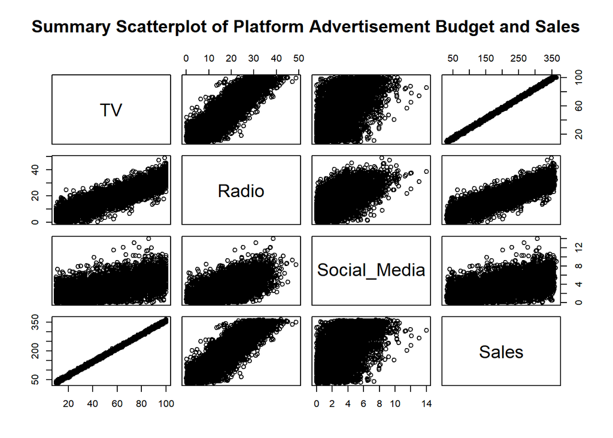

```r
plot(platform_new, main = "Summary Scatterplot of Platform Advertisement Budget and Sales")
```

##### 1.1) Television Advertisement Budget and Sales

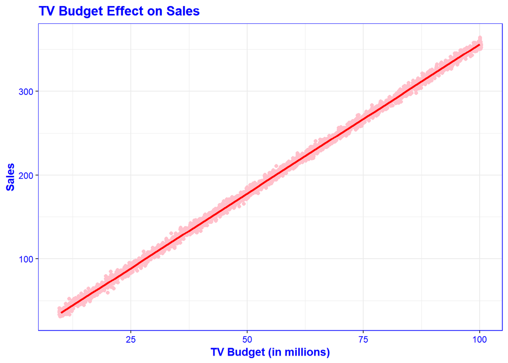

```r
ggplot(data = platform_new, aes(x = TV, y = Sales)) +
  theme +
  geom_point(position = "jitter", colour = "pink") +
  geom_smooth(colour = "red") +
  ggtitle("TV Budget Effect on Sales") +
  xlab("TV Budget (in millions)") +
  ylab("Sales")
```

##### The graph displays a positive linear relationship between TV advertisement budget and sales. The more the company invests on TV advertisements, the company is able to achieve higher sales. To reach a sale of 300 million above, at least 80 million should be invested in TV marketing.

##### 1.2) Radio Advertisement Budget and Sales

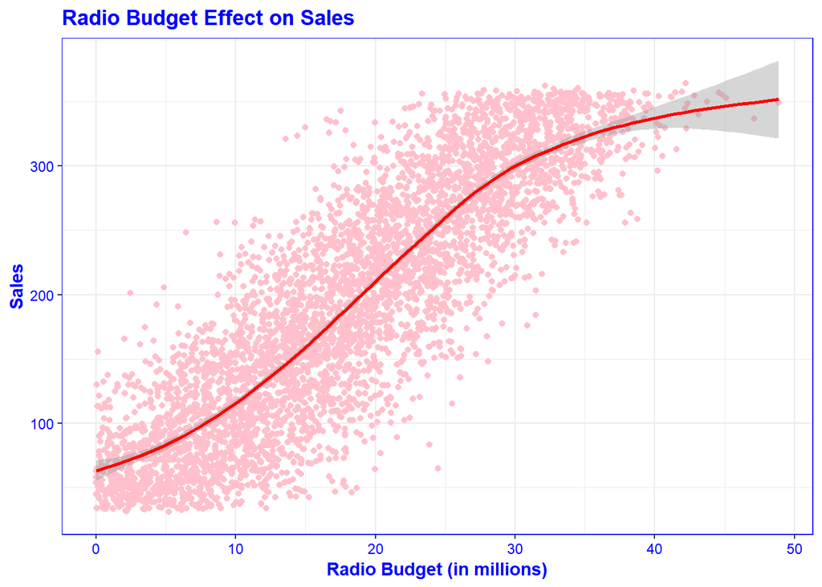

```r
ggplot(data = platform_new, aes(x = Radio, y = Sales)) +
  theme +
  geom_point(position = "jitter", colour = "pink") +
  geom_smooth(colour = "red")+
  ggtitle("Radio Budget Effect on Sales") +
  xlab("Radio Budget (in millions)")+
  ylab("Sales")
```

##### 1.3) Social Media Advertisement Budget and Sales

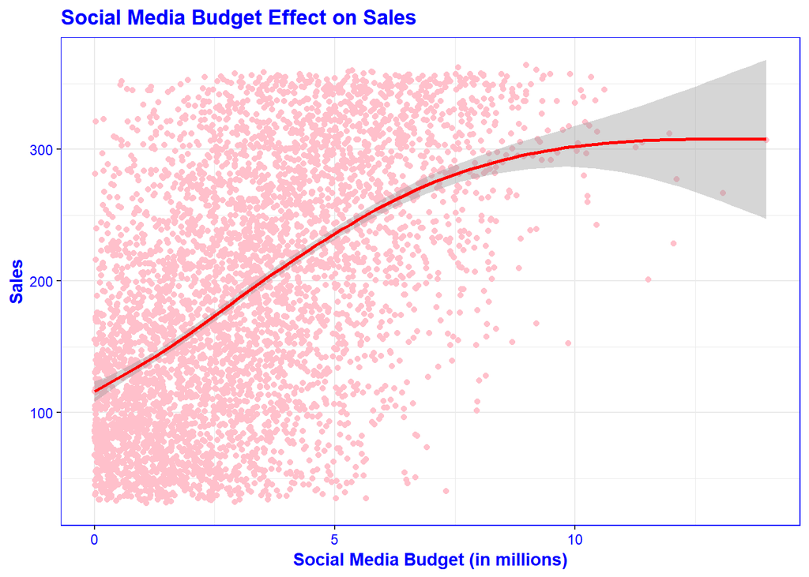

```r
ggplot(data = platform_new, aes(x = Social_Media, y = Sales)) +
  theme +
  geom_point(position = "jitter", colour = "pink") +
  geom_smooth(colour = "red")+
  ggtitle("Social Media Budget Effect on Sales") +
  xlab("Social Media Budget (in millions)")+
  ylab("Sales")
```

##### The datasets on the graph are approximately located on the left side, meaning that social media marketing costs less compared to traditional media (TV and Radio). The trend of the graph is similar to the graph of radio budget. The budget for social media advertising ranges until 15 million which is the smallest among the three platforms. The optimal point in this graph is when the sales is at 300 million. Therefore, it is most efficient to invest around 10 million to get the highest possible sales without loss.

#### 2) Social Media Platform Usage Per Year

##### 2.1) Social Media Platform Usage Statistics

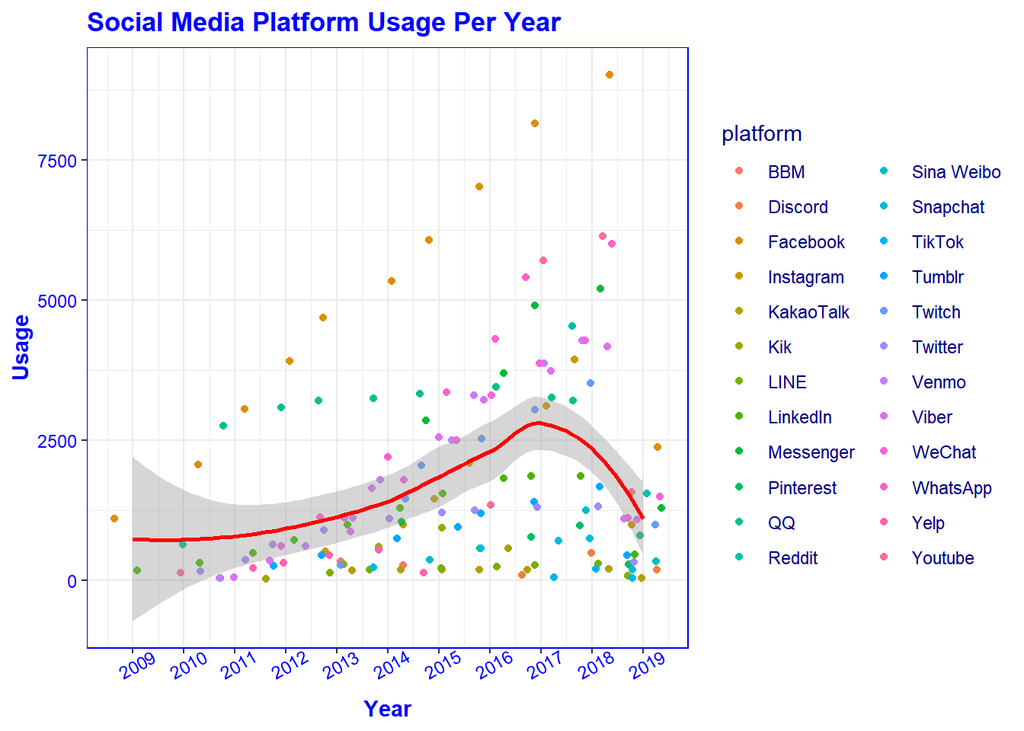

```r
ggplot(data = sns_new, mapping = aes(x = year, y = usage)) +
  theme +
  geom_point(mapping = aes(color = platform), position = "jitter") +
  geom_smooth(colour = "red") +
  ggtitle("Social Media Platform Usage Per Year") +
  xlab("Year") +
  ylab("Usage") +
  scale_fill_discrete(name = "Platforms") +
  scale_x_continuous(breaks = c(2009, 2010, 2011, 2012, 2013, 2014,
                                2015, 2016, 2017, 2018, 2019)) +
  theme(
    legend.title = element_text(colour = "navy"),
    legend.text = element_text(colour = "navy"),
    legend.background = element_blank(),
    axis.text.x = element_text(angle = 30)
  )
```

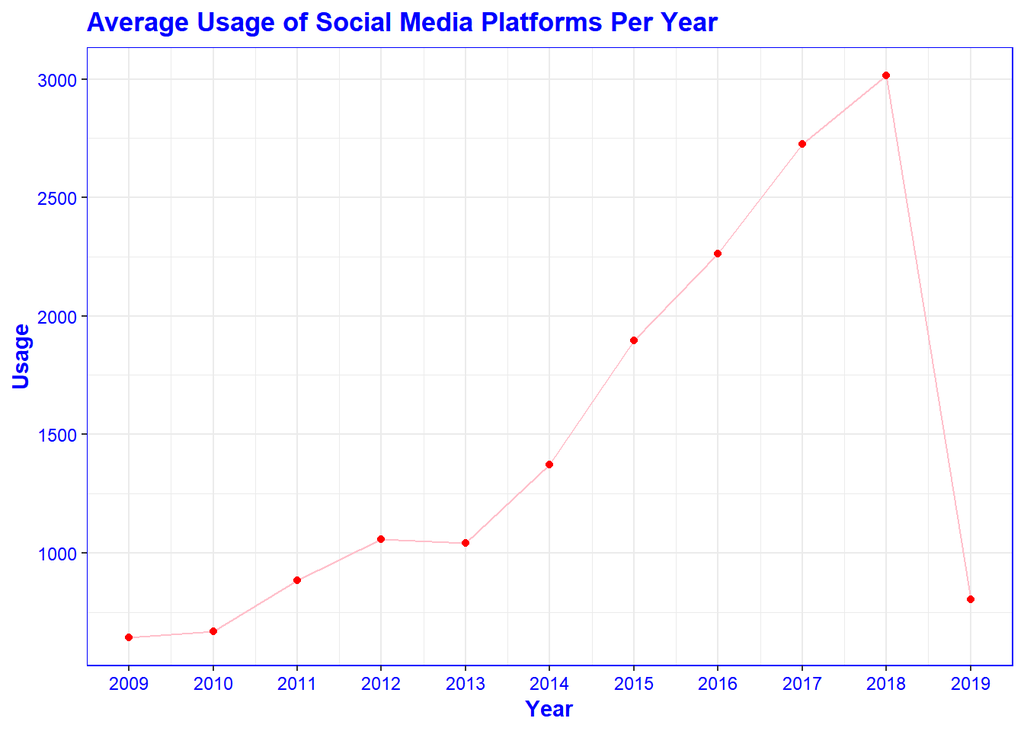

```r
sns_avg_yr <- sns_new %>%
  select(year, usage) %>%
  group_by(year) %>%
  summarise(usage = mean(usage))

ggplot(data = sns_avg_yr, aes(x = year, y = usage)) +
  theme +
  geom_line(colour = "pink")+
  geom_point(colour = "red") +
  ggtitle("Average Usage of Social Media Platforms Per Year") +
  xlab("Year") +
  ylab("Usage")+
  scale_x_continuous(breaks = c(2009, 2010, 2011, 2012, 2013, 2014,
                                2015, 2016, 2017, 2018, 2019))
```

##### There has been a steady increase of social media platform usage from 2009 to 2018. Afterwards,social media platform usage has declined. Social media platform usage was increasing because more and more platforms were being developed and entering the software market. As seen in the graph, 2009 had only two social media platforms and the numbers grew as the years went by. The possible reasons for declinement is that after the boom of social media platforms at around 2018, people tend to use more the convenient and most-known sites such as Facebook and Youtube. Until the boom, many were using various social media platforms as it was the time where many platforms were released and users were also still new to the social networking world. However, after the boom, only few number of sites survived and became the main social networking platform that most people uses.

##### 2.2) Most Used Social Media Platform Analysis

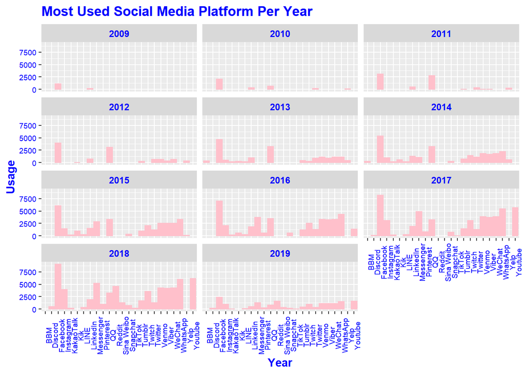

```r
ggplot(data = sns_new, aes(x = platform, y = usage, color = usage)) +
  geom_col(fill = "pink", colour = "pink") +
  facet_wrap(~ year, nrow = 4) +
  theme(
    axis.text.x = element_text(angle = 90),
    legend.position = "none"
  ) +
  ggtitle("Most Used Social Media Platform Per Year") +
  xlab("Year") +
  ylab("Usage") +
  theme(
    plot.title = element_text(colour = "blue", face = "bold"),
    axis.title = element_text(colour = "blue", face = "bold"),
    axis.text.y = element_text(colour = "blue", size = 7),
    axis.text.x = element_text(colour = "blue", angle = 90, size = 7),
    strip.text = element_text(colour = "blue", face = "bold")
  )
```

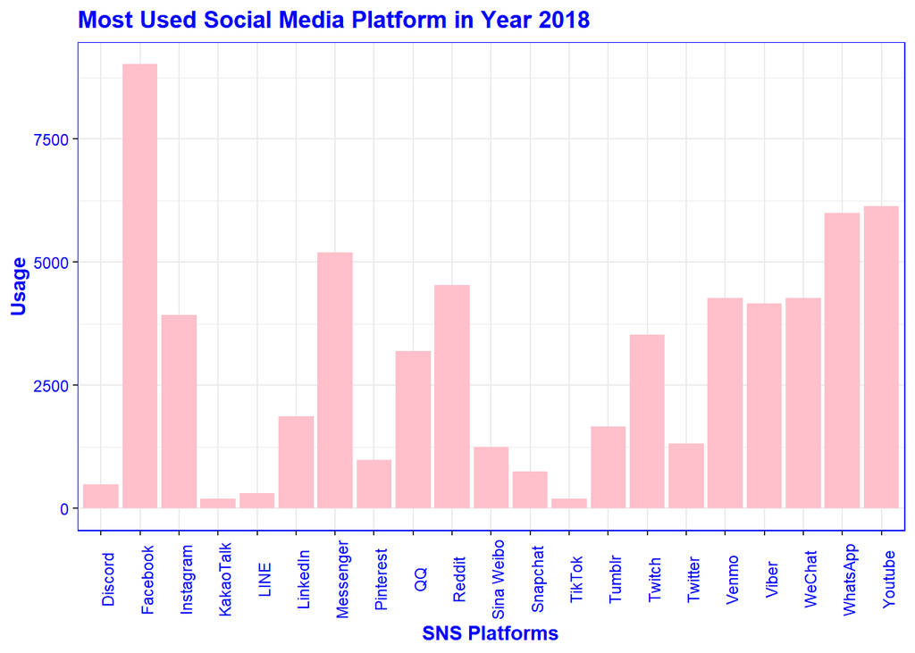

```r
sns_2018 <- sns_new %>%
  filter(year == 2018)

ggplot(data = sns_2018, aes(x = platform, y = usage)) +
  theme +
  geom_col(fill = "pink") +
  theme(
    axis.text.x = element_text(angle = 90)
  ) +
  ggtitle("Most Used Social Media Platform in Year 2018") +
  xlab("SNS Platforms") +
  ylab("Usage")
```

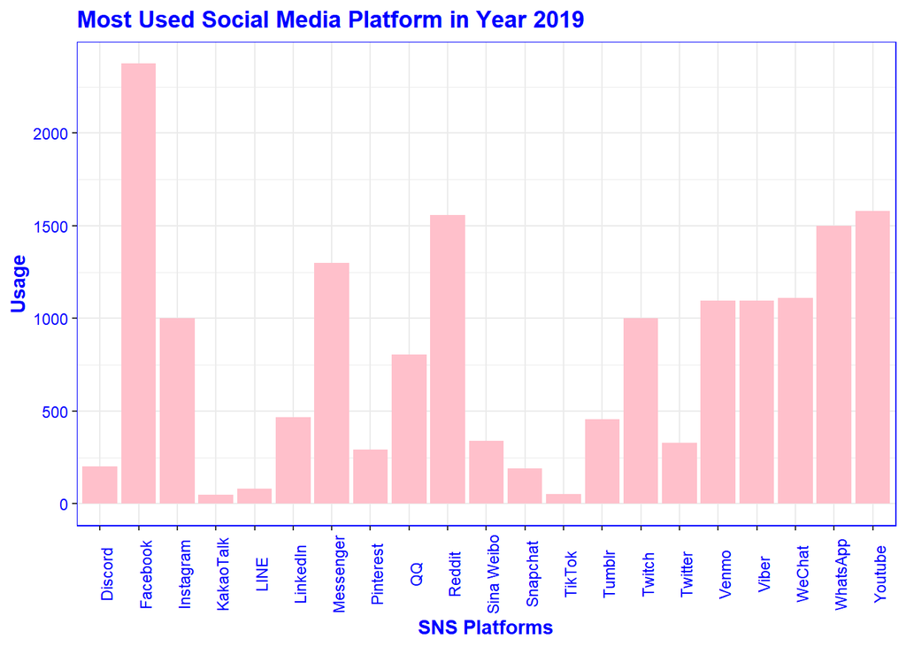

```r
sns_2019 <- sns_new %>%
  filter(year == 2019)

ggplot(data = sns_2019, aes(x = platform, y = usage)) +
  theme +
  geom_col(fill = "pink") +
  theme(
    axis.text.x = element_text(angle = 90)
  ) +
  ggtitle("Most Used Social Media Platform in Year 2019") +
  xlab("SNS Platforms") +
  ylab("Usage")
```

### 2. Website Analysis

#### 1) Website Page Type Frequency, Duration, and Others

##### 1.1) Average Values for Each Visitor Type

```r
website_avg <- website_new %>%
  select(-(holiday:revenue)) %>%
  group_by(visitor_type) %>%
  summarise(
    administrative = mean(administrative),
    administrative_duration = mean(administrative_duration),
    informational = mean(informational),
    informational_duration = mean(informational_duration),
    product_related = mean(product_related),
    product_related_duration = mean(product_related_duration),
    exit_rates = mean(exit_rates),
    bounce_rates = mean(bounce_rates),
    page_values = mean(page_values)
  )

website_avg
```

| visitor_type | administrative | administrative_duration | informational | informational_duration | product_related | product_related_duration | exit_rates | bounce_rates | page_values |
| --- | --- | --- | --- | --- | --- | --- | --- | --- | --- |
| New | 2.551948 | 91.91131 | 0.3335301 | 19.23747 | 18.05490 | 636.3934 | 0.02068052 | 0.005261159 | 10.772187 |
| Other | 1.470588 | 62.69559 | 0.1764706 | 11.68549 | 12.47059 | 570.4049 | 0.06334867 | 0.038551364 | 18.191812 |
| Returning | 2.283954 | 79.18364 | 0.5335039 | 37.10199 | 34.08246 | 1289.4215 | 0.04650461 | 0.024777789 | 5.006176 |

##### 1.2) Website Page Type Statistics

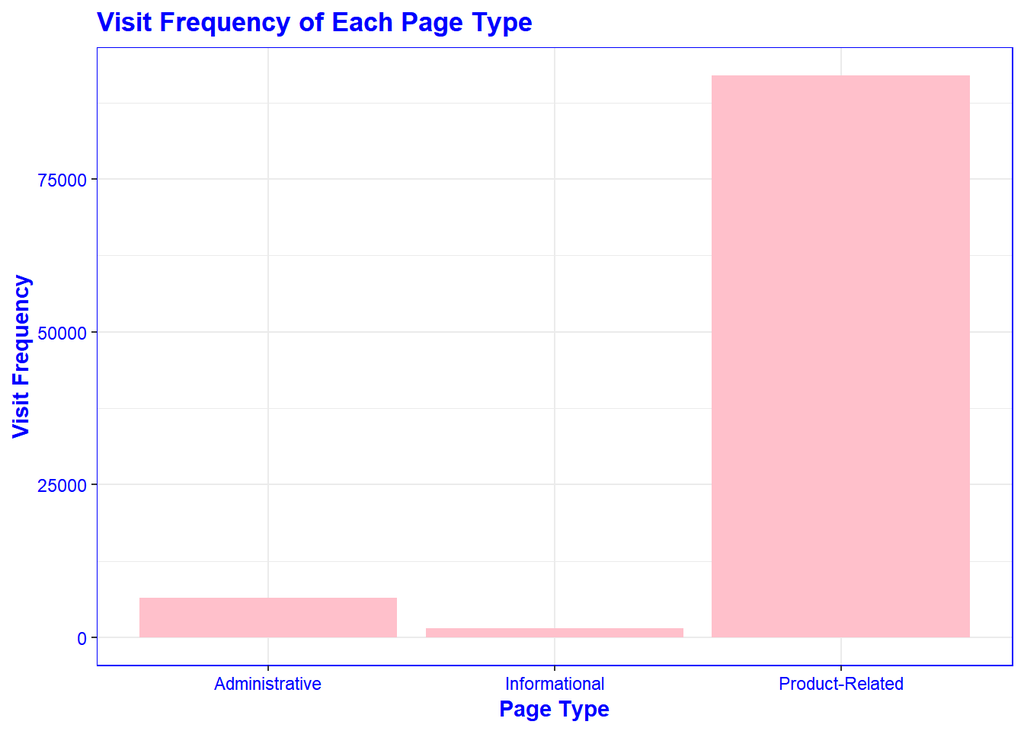

```r
website_pg <- website_new %>%
  filter(revenue == "TRUE") %>%
  select(administrative, informational, product_related, revenue) %>%
  gather(page, count, administrative:product_related)

ggplot(data = website_pg, aes(x = page, y = count)) +
  theme +
  geom_col(fill = "pink") +
  ggtitle("Visit Frequency of Each Page Type") +
  xlab("Page Type") +
  ylab("Visit Frequency") +
  scale_x_discrete(
    labels = c("Administrative", "Informational", "Product-Related")
  )
```

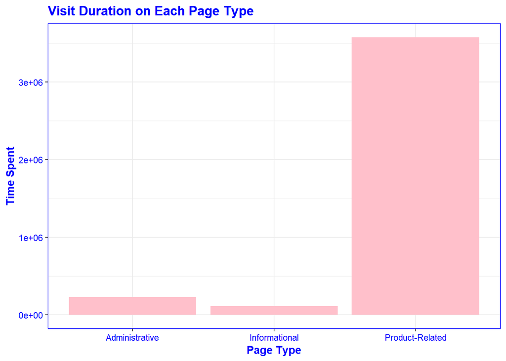

```r
website_dur <- website_new %>%
  filter(revenue == "TRUE") %>%
  select(administrative_duration, informational_duration, product_related_duration, revenue) %>%
  gather(page, duration, administrative_duration:product_related_duration) %>%
  mutate(
    page = str_extract(page, "([^_]+)")
  )

ggplot(data = website_dur, aes(x = page, y = duration)) +
  theme +
  geom_col(fill = "pink") +
  ggtitle("Visit Duration on Each Page Type") +
  xlab("Page Type") +
  ylab("Time Spent") +
  scale_x_discrete(
    labels = c("Administrative", "Informational", "Product-Related")
  )
```

##### It can be seen that the visitors spends the most time on product-related pages on the company’s website. This means that the company should focus on improving and updating frequently these pages. The company should concentrate on the keyword search relevance function for the customers to access easily and promptly the products they are looking for. In addition, it is important for the company to find the nicest layout wherein the customers can conveniently shop and see the details of the product. The company should focus on the product displayment page in order to maintain visitors of the company’s website.

##### 1.3) Holiday and Weekend Effect on Revenue

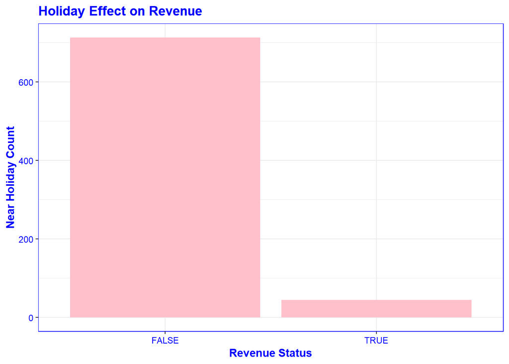

```r
website_ho <- website_new %>%
  filter(holiday!=0) %>%
  select(holiday, revenue)

ggplot(data = website_ho, aes(x = revenue, y = holiday)) +
  theme +
  geom_col(fill = "pink") +
  ggtitle("Holiday Effect on Revenue") +
  xlab("Revenue Status") +
  ylab("Near Holiday Count")
```

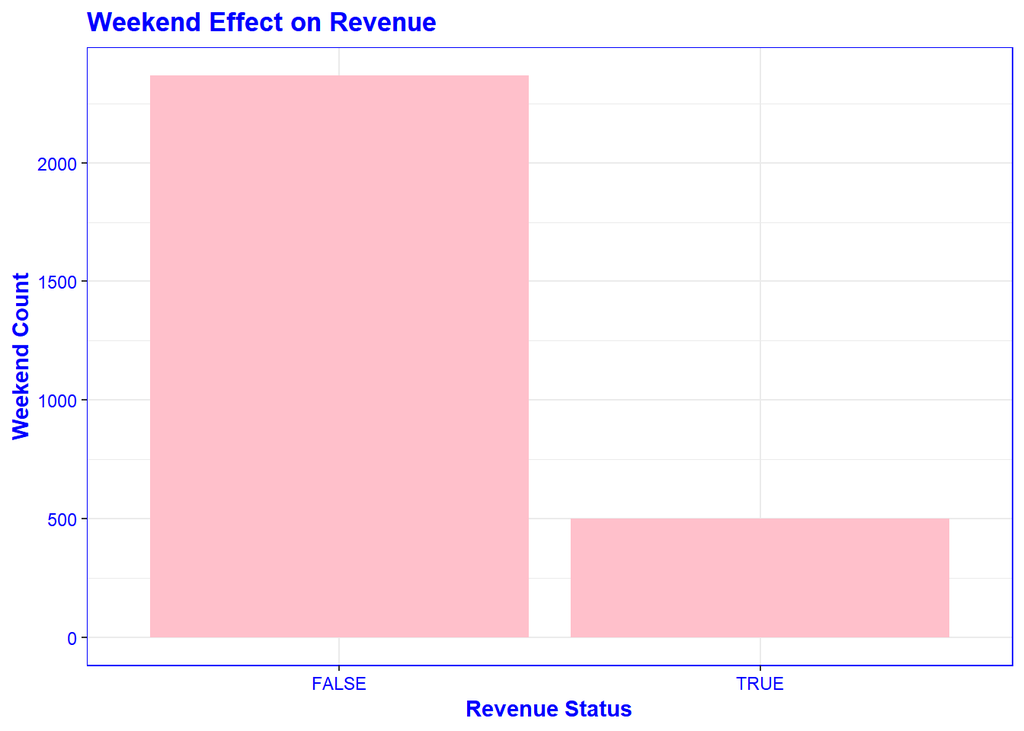

```r
website_we <- website_new %>%
  filter(weekend == "TRUE") %>%
  select(weekend, revenue)

ggplot(data = website_we, aes(x = revenue)) +
  theme +
  geom_bar(fill = "pink")+
  ggtitle("Weekend Effect on Revenue") +
  xlab("Revenue Status") +
  ylab("Weekend Count")
```

##### It has been analysed whether holidays and weekends are important factors in increasing transactions made in the website. The bar graph shows that holidays and weekends are not significant factors in increasing transactions. As holidays are coming near, the revenue status is false. Likewise, there are more false revenue status on weekends. Therefore, the company does not have to prioritize the weekend or holiday promotions in order to maintain visitors and increase transactions. But rather, it is more efficient to make the product displayment page more convenient to use and easy to access.

#### 2) Category Keyword Search Relevance

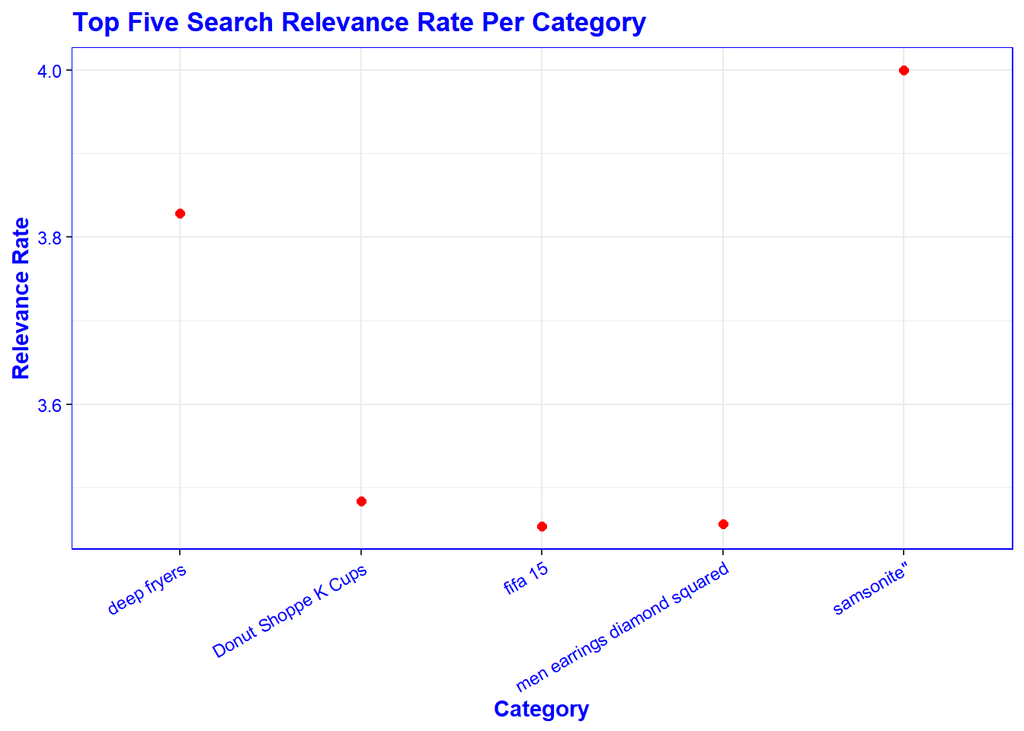

```r
keyword_top <- keyword_new %>%
 top_n(5, relevance)

ggplot(data = keyword_top, aes(x=category, y=relevance)) +
  theme +
  geom_point(colour = "red", size = 2) +
  theme(
    axis.text.x = element_text(angle = 30, hjust = 1, vjust = 1)
  ) +
  ggtitle("Top Five Search Relevance Rate Per Category") +
  xlab("Category") +
  ylab("Relevance Rate")
```

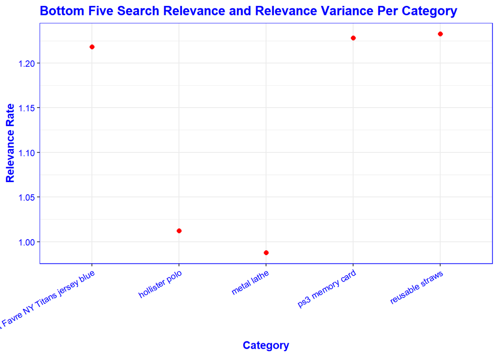

```r
keyword_bot <- keyword_new %>%
 top_n(-5, relevance)

ggplot(data = keyword_bot, aes(x=category, y=relevance)) +
  theme +
  geom_point(colour = "red", size = 2) +
  theme(
    axis.text.x = element_text(angle = 30, hjust = 1, vjust = 1)
  ) +
  ggtitle("Bottom Five Search Relevance and Relevance Variance Per Category") +
  xlab("Category") +
  ylab("Relevance Rate")
```

##### The graphs display the keyword search relevance for each product cateogory. The category of luggage has the highest relevance rate while a product called metal lathe has the lowest relevance rate. The company should assign more keywords related to the product in order to achieve a higher relevance rate. This is important in maintaining visitors of the website and increasing transactions.

## **VI. Recommendation**

##### It is recommended that the company will budget at around 80 million for TV marketing, 30 million for radio marketing, and 10 million for social media marketing to achieve the most efficient sales.

##### As for social media platforms, companies should focus on big platforms that wide range of people uses such as Facebook, Youtube, and Reddit. People are interested in sharing ideas and contents online, so it would be efficient for companies to think of marketing strategies that would engage more users to talk about the company and products in the online community. The company should find ways to make their website more compatible on those social media platforms and reach customers that would be potential customers.

##### In addition, companies should focus on making the product-related pages better. The products should be displayed in a nice format and the details should be easily accessible to online shoppers. Since visitors stay the most on product-related pages, it is a priority for the company to directly transport visitors to the products they are finding for. Consequently. keyword search relevance is important in achieving this. Therefore, companies should continuously check the search relevance rate of products and supplement more keywords for the products that has low keyword search relevance rates.

## **VII. References**

#### 1. Datasets:

###### 1) Dummy Marketing and Sales Data (https://www.kaggle.com/harrimansaragih/dummy-advertising-and-sales-data?select=Dummy+Data+HSS.csv) -> platform

###### 2) Most Used Social Media Platforms (https://www.kaggle.com/mathurinache/mostusedsocialmediaplatforms) -> sns

###### 3) Online Shoppers Purchasing Intention (https://archive.ics.uci.edu/ml/datasets/Online+Shoppers+Purchasing+Intention+Dataset#) -> website

###### 4) Ecommerce seach relevance (https://data.world/crowdflower/ecommerce-search-relevance) -> keyword

#### 2. Sites:

###### 1) Shopify Business Encyclopedia (https://www.shopify.com/encyclopedia/what-is-ecommerce#:~:text=Ecommerce%2C%20also%20known%20as%20electronic,data%20to%20execute%20these%20transactions)

###### 2) Ecommerce boom fuels record online competition (https://www.shopify.com/enterprise/the-future-of-ecommerce/omnichannel)